# User Guide: 1 Debugging ggplots

# Controlling the debug output

In the examples above we have demonstrated the use of the statistics and geometries using default arguments. Here we show examples of generation of other types of debug output.

## Display debug output on the plot

Differently to `geom_debug()` where the data can only be printed to the console, `stat_debug_group()` and `stat_debug_panel()` return data that can be plotted using a geometry. If we use as geometries `"label"` or `"text"` a *debug* summary is added to the plot itself, we can also pass other arguments valid for the geometry used, in this case `vjust`.

```
## [1] "Input 'data' to 'compute_group()':"
## # A tibble: 50 x 5
##        x       y shape PANEL group
##    <dbl>   <dbl> <fct> <fct> <int>
##  1     1 -27205. A     1         1
##  2     3  45791. A     1         1
##  3     5  -8029. A     1         1
##  4     7 -18547. A     1         1
##  5     9  79924. A     1         1
##  6    11  -2824. A     1         1
##  7    13 -78017. A     1         1
##  8    15 -74281. A     1         1
##  9    17   9904. A     1         1
## 10    19 -94023. A     1         1
## # ... with 40 more rows
## [1] "Input 'data' to 'compute_group()':"
## # A tibble: 50 x 5
##        x       y shape PANEL group
##    <dbl>   <dbl> <fct> <fct> <int>
##  1     2 -14243. B     1         2
##  2     4  53731. B     1         2
##  3     6 102864. B     1         2
##  4     8  13081. B     1         2
##  5    10 -44711. B     1         2
##  6    12  23840. B     1         2
##  7    14  75602. B     1         2
##  8    16 104677. B     1         2
##  9    18 -68747. B     1         2
## 10    20 -39230. B     1         2
## # ... with 40 more rows
```

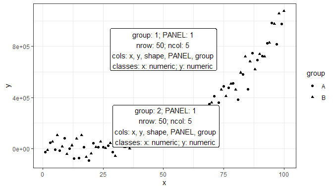

```r
ggplot(my.data, aes(x, y, shape = group)) +
  geom_point() +
  stat_debug_group(geom = "label", vjust = c(-0.5,1.5))
```

This approach is of limited use except for highlighting groups and panels, possible when learning or teaching how ggplots are assembled.

```
## [1] "Input 'data' to 'compute_panel()':"
## # A tibble: 50 x 5
##        x       y colour PANEL group
##    <dbl>   <dbl> <fct>  <fct> <int>
##  1     1 -27205. A      1         1
##  2     2 -14243. B      1         2
##  3     5  -8029. A      1         1
##  4     6 102864. B      1         2
##  5     9  79924. A      1         1
##  6    10 -44711. B      1         2
##  7    13 -78017. A      1         1
##  8    14  75602. B      1         2
##  9    17   9904. A      1         1
## 10    18 -68747. B      1         2
## # ... with 40 more rows
## [1] "Input 'data' to 'compute_panel()':"
## # A tibble: 50 x 5
##        x       y colour PANEL group
##    <dbl>   <dbl> <fct>  <fct> <int>
##  1     3  45791. A      2         1
##  2     4  53731. B      2         2
##  3     7 -18547. A      2         1
##  4     8  13081. B      2         2
##  5    11  -2824. A      2         1
##  6    12  23840. B      2         2
##  7    15 -74281. A      2         1
##  8    16 104677. B      2         2
##  9    19 -94023. A      2         1
## 10    20 -39230. B      2         2
## # ... with 40 more rows
```

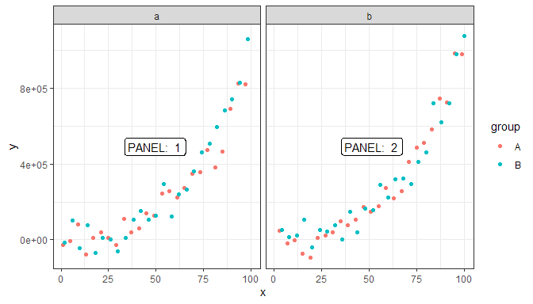

```r
ggplot(my.data, aes(x, y, colour = group)) +
  geom_point() +
  stat_debug_panel(geom = "label", aes(label = stat(paste("PANEL: ", PANEL)))) +
  facet_wrap(~block)
```

Of course to see all the returned variables, we can use `geom_debug()`.

```
## [1] "Input 'data' to 'compute_group()':"
## # A tibble: 50 x 5
##        x       y shape PANEL group
##    <dbl>   <dbl> <fct> <fct> <int>
##  1     1 -27205. A     1         1
##  2     3  45791. A     1         1
##  3     5  -8029. A     1         1
##  4     7 -18547. A     1         1
##  5     9  79924. A     1         1
##  6    11  -2824. A     1         1
##  7    13 -78017. A     1         1
##  8    15 -74281. A     1         1
##  9    17   9904. A     1         1
## 10    19 -94023. A     1         1
## # ... with 40 more rows
## [1] "Input 'data' to 'compute_group()':"
## # A tibble: 50 x 5
##        x       y shape PANEL group
##    <dbl>   <dbl> <fct> <fct> <int>
##  1     2 -14243. B     1         2
##  2     4  53731. B     1         2
##  3     6 102864. B     1         2
##  4     8  13081. B     1         2
##  5    10 -44711. B     1         2
##  6    12  23840. B     1         2
##  7    14  75602. B     1         2
##  8    16 104677. B     1         2
##  9    18 -68747. B     1         2
## 10    20 -39230. B     1         2
## # ... with 40 more rows
## # A tibble: 2 x 10
##   shape label             x      y  nrow  ncol colnames  colclasses  group PANEL
##   <dbl> <chr>         <dbl>  <dbl> <int> <int> <fct>     <fct>       <fct> <fct>
## 1    16 "group: 1; P~    50 4.45e5    50     5 x, y, sh~ x: numeric~ 1     1
## 2    17 "group: 2; P~    51 5.04e5    50     5 x, y, sh~ x: numeric~ 2     1
```

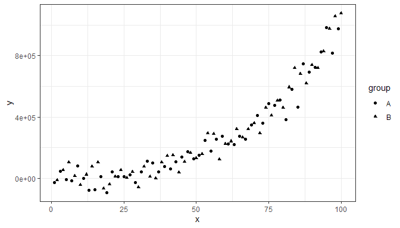

```r
ggplot(my.data, aes(x, y, shape = group)) +
  geom_point() +
  stat_debug_group(geom = "debug")
```

# Assign debug output to a variable

In the next example we show how to save the data input of the geom to a variable in the global environment. However, assignment takes place at the time the ggplot object is printed. An approach like this could be used to capture the data output of statistics in automated code tests.

```r
pipe_assign <- function(value, name, pos = .GlobalEnv, ...) {
  assign(x = name, value = value, inherits = FALSE, pos = pos, ...)
}

ggplot(my.data, aes(x, y, colour = group)) +
  geom_point() +
  geom_debug(summary.fun = pipe_assign,
             summary.fun.args = list(name = "debug_data"),
             print.fun = NULL)

head(debug_data)
```

```
##    colour x          y PANEL group
## 1 #F8766D 1 -27205.450     1     1
## 2 #00BFC4 2 -14242.651     1     2
## 3 #F8766D 3  45790.918     1     1
## 4 #00BFC4 4  53731.420     1     2
## 5 #F8766D 5  -8028.578     1     1
## 6 #00BFC4 6 102863.943     1     2
```